# GSA Buildings

## Question 3

Since the “Owned or Leased” column is categorical I first had to convert the two options into a binary variable so that “OWNED” became 1 and “LEASED” became 0. Then I ran a linear regression model and found out that the R squared value was 0.07045 which means that the rentable square footage explains about 7.045% percent of the variation in ownership status. The p-value was < 2.2 x 10^-16 which is extremely small and suggests that the results are statistically significant and that a relationship between the rentable square footage and ownership status exists. The coefficient is 8.585 x 10^-7 which is positive and it can be seen in the scatter plot since the regression line is going upwards towards “Owned” as the rentable square footage of a building increases. This supports my hypothesis that a building is more likely to be owned as the rentable square footage increases because of the positive regression line.

```r
GSA$Owned_Binary <- ifelse(GSA$Owned.or.Leased == "OWNED", 1, 0)

model <- lm(Owned_Binary ~ GSA$Building.Rentable.Square.Feet, data = GSA)

summary(model)
```

```
##
## Call:
## lm(formula = Owned_Binary ~ GSA$Building.Rentable.Square.Feet,
##     data = GSA)
##
## Residuals:
##     Min      1Q  Median      3Q     Max
## -1.5709 -0.1923 -0.1831 -0.1780  0.8229
##
## Coefficients:
##                                    Estimate Std. Error t value Pr(>|t|)
## (Intercept)                       1.771e-01  4.779e-03   37.05   <2e-16 ***
## GSA$Building.Rentable.Square.Feet 8.585e-07  3.539e-08   24.26   <2e-16 ***
## ---
## Signif. codes:  0 '***' 0.001 '**' 0.01 '*' 0.05 '.' 0.1 ' ' 1
##
## Residual standard error: 0.3968 on 7766 degrees of freedom
## Multiple R-squared:  0.07045,    Adjusted R-squared:  0.07033
## F-statistic: 588.6 on 1 and 7766 DF,  p-value: < 2.2e-16
```

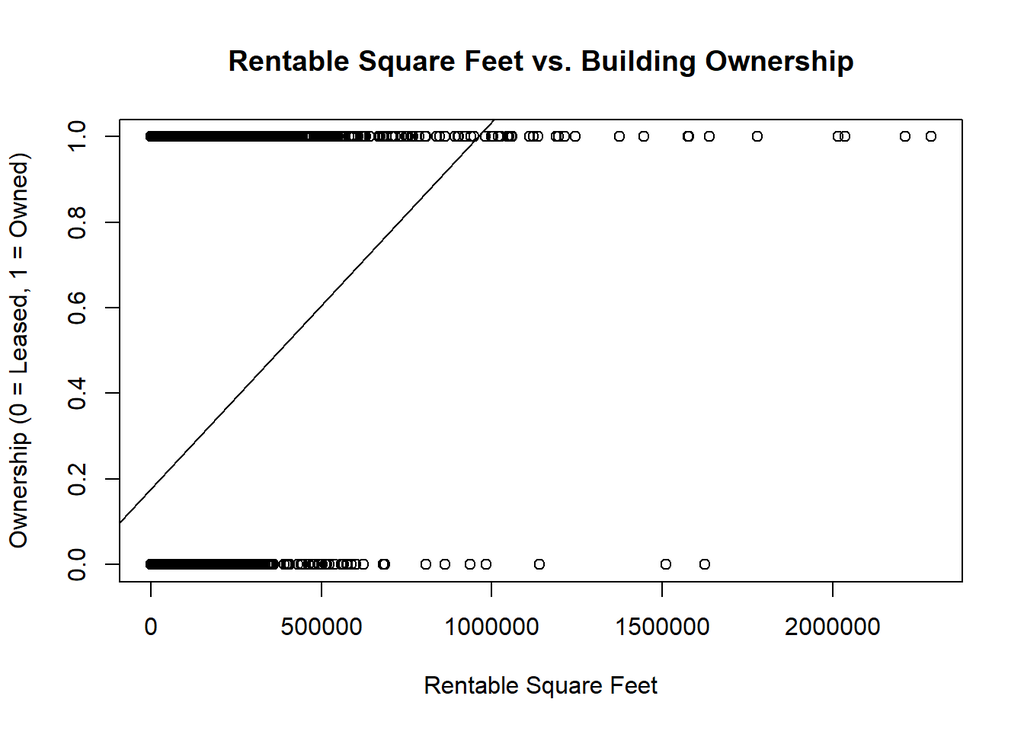

```r
plot(GSA$Building.Rentable.Square.Feet,
     GSA$Owned_Binary,
     main = "Rentable Square Feet vs. Building Ownership",
     xlab = "Rentable Square Feet",
     ylab = "Ownership (0 = Leased, 1 = Owned)")

abline(model)
```